# Animal activity analysis

Francisco E. Fonturbel and Javier Cuadra

26/jun/2019

# 02 - Circular statistics

[figure not shown]

**Circular statistics** are an analytic approach to deal with time data. Here we will use the `circular` package to deal with animal activity data, and the `plotrix` package to produce some plots.

```r
#Loading the libraries needed to work with circular data and do plots
library("circular")
library("plotrix")

#Loading an example dataset
activ<-read.table("./data/activity.txt", header= T)
```

### Data (time) transformation to radians

A given time, say 15:26 h in a 24h clock can be also expressed as a radian in a circle. Therefore, before start analyzing activity data we should transform time data to radians using the following formula:

$$rad=time*2*{\pi}$$
**Important:** Prior to transform time data to radians you must convert your time figures to a number.

```r
radian <- activ$Time_2*2*pi
data <- radian[activ$Condition == "A"]
```

Then, we have to convert our radian data into a `circular class` object in order to be used with the `circular` package.

```r
as.circular(data)
```

```
## Circular Data:
## Type = angles
## Units = radians
## Template = none
## Modulo = asis
## Zero = 0
## Rotation = counter
##   [1] 2.146755 2.635447 3.490659 4.118977 4.708026 2.033309 2.238385 2.779437
##   [9] 3.032510 3.281219 3.464479 3.608468 3.796091 3.948807 4.084070 4.293510
##  [17] 4.476770 2.037672 2.203478 2.548181 2.696534 3.647738 4.372050 2.103122
##  [25] 2.356194 2.583087 2.072578 3.154683 3.652101 3.852814 4.053527 4.271693
##  [33] 4.598943 4.319690 3.241949 4.114614 4.393866 4.625123 2.347468 3.490659
##  [41] 3.708825 3.926991 4.507313 1.994039 2.146755 2.286381 3.508112 3.660828
##  [49] 3.817908 3.953171 4.293510 4.568399 4.747296 2.539454 2.792527 3.058690
##  [57] 3.337942 3.577925 3.752458 4.101524 4.354596 4.564036 4.712389 1.954769
```

[output cut: 60 more lines]

```r
n_a <- circular(data%%24,
                     units="radians", template="clock24")
```

## Rose diagrams

A simple representation of activity data is the rose diagram, which is obtained using the function `rose.diag` to represent a circular dataset into a 24h clock.

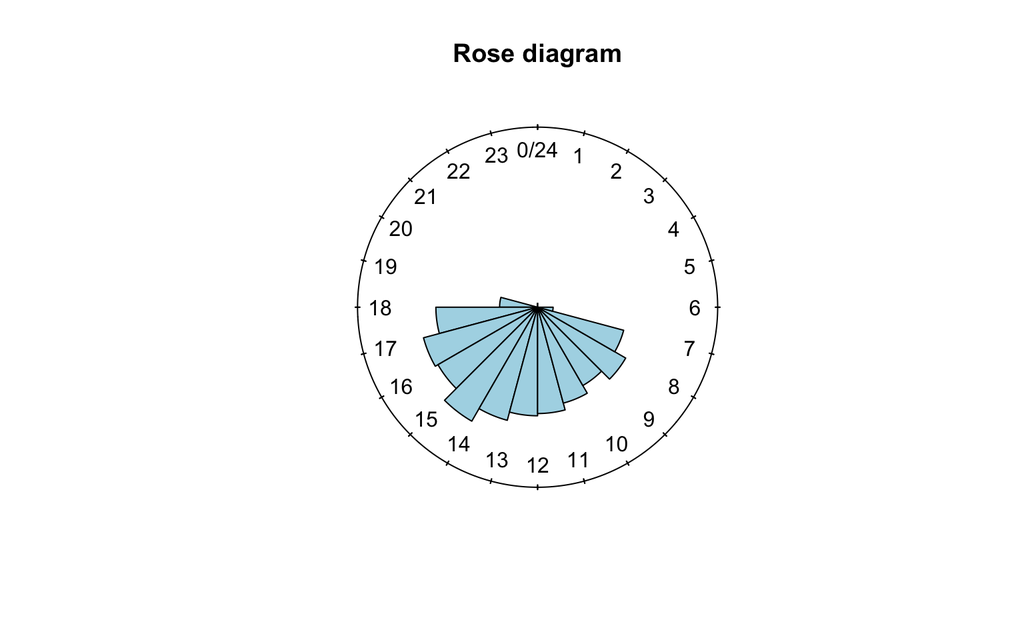

```r
rose.diag(n_a, bin = 24, col = "lightblue", main = "Rose diagram",
          prop = 2)
```

## Frequency plots

To make a decent frequency plot we need to arrange our data in a table with frequency of records per hour. We’ll load a new file (ready to go) as example.

Then, we will use the `clock24.plot` function of the `plotrix` package.

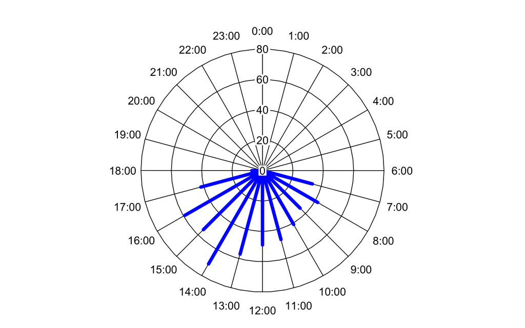

```r
#Loading new data file
activ_table<-read.table("./data/records_hour.txt", header= T)

#Making the plot
clock<-c(0:23)
clock24.plot(activ_table$A,clock, minutes=T, label.prop=c(1.15,1.15),show.grid.labels = 3,  show.grid=T, grid.bg="white", grid.left=T,grid.col="black",rad.col="black", rp.type="r",lwd=5,line.col="blue",lty=1, main="",add=F)
```

Another way to represent the frequency plot is with the magnitudes represented by the positions of the vertices of the polygon. In this plot, the positions of the vertices indicate the frequency of the records.

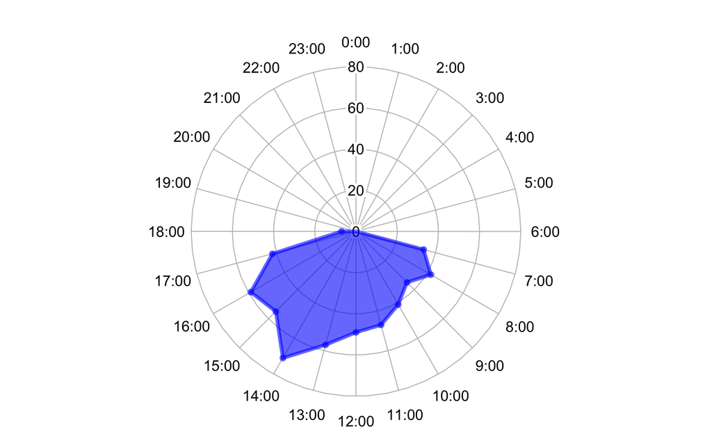

```r
#Making the plot
clock<-c(0:23)
mi.azul <- rgb(0, 0, 1, 0.6) # "#0000FF99"
clock24.plot(activ_table$A,clock,minutes=T,label.prop=c(1.15,1.15),show.grid.labels = 3, rp.type="s",point.symbols=16,point.col="#0000FF99",add=F)
clock24.plot(activ_table$A,clock, rp.type="p",poly.col="#0000FF99",lwd=4,line.col="#0000FF99",lty=1, main="",add=T)
```

## Formal tests

Now that we have made such beautiful rose diagrams and frequency plots, we maybe will be interested into test some hypotheses about activity patterns. The most simple question here will be if animal activity is homogeneous or not along the day. Of course our *null hypothesis* will be that animal activity is uniform along the day (like a faculty researcher, for example). The `circular` package has two common tests to do that: Rao’s test for homogeneity of angular data (`rao.test` function), and Rayleight test of Unifortmity (`rayleigh.test` function). Both tests do basically the same, the difference is that Rayleigh test needs only one `circular.class` element whereas Rao’s test need two samples to be compared.

Let’s see how they work:

```r
#Rao's test
x <- rvonmises(100, circular(0), kappa=10)
y <- rvonmises(100, circular(0), kappa=10)

rao.test(x, y)
```

```
##
## Rao's Tests for Homogeneity
##
##        Test for Equality of Polar Vectors:
##
## Test Statistic = 3.1008
## Degrees of Freedom = 1
## P-value of test = 0.0783
##
##        Test for Equality of Dispersions:
##
## Test Statistic = 0.3045
## Degrees of Freedom = 1
## P-value of test = 0.5811
##
```

```r
#Rayleigh's test
rayleigh.test(n_a)
```

```
##
##        Rayleigh Test of Uniformity
##        General Unimodal Alternative
##
## Test Statistic:  0.7168
## P-value:  0
```

Licensing Creative Commons License

Licensed under a Creative Commons Attribution-ShareAlike 4.0 International License.  
2019 - Francisco E. Fontúrbel